# Version comparison: Program-Area / Planning-Area scores

Parameterized report — overall composite and every component score, two releases side by side

Published

2026-09-20

> **Not a pipeline stage** — a standalone, parameterized *report* (no `msens:` target block, so `tar_make()` never runs it). Render it on demand for any two release versions whose `sdm.duckdb` are on disk. The reusable comparison **core lives in `msens`** (`zone_scored_flds`, `zone_scores`, `zone_crosswalk`, `zone_score_delta`, `score_delta`, `score_delta_summary`, `assert_within_tolerance`) so this notebook only *orchestrates* — the math is unit-tested in `msens/tests/testthat/test-validate.R` and can’t drift from what’s reported here.

> ```r
> # render with version suffixes in the output filename (see scripts/render_compare.R):
> source("scripts/render_compare.R"); render_compare("v6", "v9")   # -> _output/compare_versions_v6_vs_v9.html
> # or from the shell:
> Rscript scripts/render_compare.R v6 v9
> ```

> **What is compared.** Scores on each release’s **principal reporting unit** — the 20 BOEM **Program Areas** (v2 onward) or, for a release that scored none, the 36 **Planning Areas** (v1). Ecoregions and subregions are deliberately not reported here. When the two releases used different units, zones are compared **only where they are the same polygon** (`msens::zone_crosswalk()`, intersection over union ≥ 0.999, computed from the polygons at render time); everything else — a Program Area that is a *subset* of a Planning Area, a Planning Area with no Program Area — is listed **adjacent, not compared**, exactly as components present in only one release (v6’s `other`, v8+’s `primary_producer`) are. The overall composite and each **component** it averages (`extrisk_{category}_ecoregion_rescaled` + `primprod_ecoregion_rescaled`) are shown. `Δ = B − A`.

## 1 Setup

```r
librarian::shelf(DBI, duckdb, dplyr, DT, ggplot2, glue, htmltools, knitr, leaflet, purrr,
                 rmapshaper, scales, sf, tidyr, MarineSensitivity/msens, quiet = TRUE)
source(here::here("libs/paths.R"))

va <- params$version_a
vb <- params$version_b
mk <- params$metric_key
stopifnot(va != vb)

# resolve each version's sdm.duckdb by swapping the version segment of the configured path
sdm_for <- function(v) sub(glue("/{ver}/"), glue("/{v}/"), path.expand(sdm_db))
db_a <- sdm_for(va); db_b <- sdm_for(vb)
stopifnot(file.exists(db_a), file.exists(db_b))

con_a <- dbConnect(duckdb(), db_a, read_only = TRUE)
con_b <- dbConnect(duckdb(), db_b, read_only = TRUE)

va_col <- glue("score_{va}"); vb_col <- glue("score_{vb}")

# the principal reporting unit each release actually scored: Program Areas if it has them, else
# Planning Areas (v1); never ecoregions or subregions
UNITS <- c(programarea = "programarea_key", planarea = "planarea_key")
unit_of <- function(con, v) {
  flds <- msens::zone_scored_flds(con, mk)
  u <- UNITS[UNITS %in% flds]
  if (!length(u)) stop(glue("{v}: no Program-Area or Planning-Area zones carry `{mk}` (has: ",
                            "{paste(flds, collapse = ', ')})"))
  names(u)[1]
}
unit_a <- unit_of(con_a, va); unit_b <- unit_of(con_b, vb)
fld_a  <- UNITS[[unit_a]];    fld_b  <- UNITS[[unit_b]]
unit_label <- c(programarea = "Program Area", planarea = "Planning Area")

cat(glue("Comparing **{va}** (A) ← → **{vb}** (B)  \n",
         "- A ({va}): `{db_a}` — scored on **{unit_label[[unit_a]]}s** (`{fld_a}`)  \n",
         "- B ({vb}): `{db_b}` — scored on **{unit_label[[unit_b]]}s** (`{fld_b}`)  \n",
         "- composite metric: `{mk}`\n"))
```

```
Comparing **v7** (A) ← → **v7b** (B)
- A (v7): `/Users/bbest/_big/msens/derived/v7/sdm.duckdb` — scored on **Program Areas** (`programarea_key`)
- B (v7b): `/Users/bbest/_big/msens/derived/v7b/sdm.duckdb` — scored on **Program Areas** (`programarea_key`)
- composite metric: `score_extriskspcat_primprod_ecoregionrescaled_equalweights`
```

### 1.1 Zone polygons

The choropleths and the crosswalk need each unit’s geometry. It is resolved from the derived tree by **content**, not by filename: every `ply_{unit}s_*.gpkg` under `dir_derived` is fingerprinted with `msens::zone_geom_hash()` and the first whose hash equals that unit’s entry in `data/zone_sets.csv` is used — so the map can never silently draw a different vintage than the scores were computed on.

```r
zone_sets <- readr::read_csv(here::here("data/zone_sets.csv"), show_col_types = FALSE)

resolve_ply <- function(unit) {
  zs <- zone_sets |> filter(zone_type == unit)
  stopifnot(nrow(zs) >= 1)
  zs <- zs[1, ]
  cands <- list.files(path.expand(dir_derived), pattern = glue("^ply_{unit}s_.*\\.gpkg$"),
                      recursive = TRUE, full.names = TRUE)
  for (f in cands) {
    x <- sf::st_read(f, quiet = TRUE)
    h <- tryCatch(msens::zone_geom_hash(x, zone_type = unit)$geom_hash, error = function(e) NA)
    if (identical(h, zs$geom_hash)) {
      key <- UNITS[[unit]]; nm <- glue("{unit}_name")
      x <- x |>
        transmute(zone_key = as.character(.data[[key]]), zone_name = .data[[nm]],
                  region = if ("region_key" %in% names(x)) region_key else NA_character_,
                  hint   = if ("planarea_key" %in% names(x) && unit != "planarea") planarea_key
                           else NA_character_) |>
        st_make_valid()
      attr(x, "src") <- f; attr(x, "zone_set_key") <- zs$zone_set_key
      return(x)
    }
  }
  stop(glue("no ply_{unit}s_*.gpkg under {dir_derived} matches geom_hash {zs$geom_hash} ",
            "({zs$zone_set_key}); candidates: {paste(cands, collapse = ', ')}"))
}
ply_a <- resolve_ply(unit_a)
ply_b <- if (unit_b == unit_a) ply_a else resolve_ply(unit_b)

for (p in unique(list(ply_a, ply_b)))
  cat(glue("- `{sub(path.expand(dir_derived), '', attr(p, 'src'))}` — {attr(p, 'zone_set_key')}, ",
           "{nrow(p)} zones\n\n"))
```

```
- `/archive_2026-02-12/downloads/ply_programareas_2026_v3.gpkg` — programarea_2026-01, 20 zones
```

### 1.2 Crosswalk: which zones are compared

```r
if (unit_a == unit_b) {
  xw <- tibble(key_a = ply_a$zone_key, key_b = ply_a$zone_key, iou = 1, identical = TRUE)
} else {
  hint <- if (!all(is.na(ply_b$hint))) "hint" else NULL
  xw <- msens::zone_crosswalk(ply_a, ply_b, "zone_key", "zone_key", hint = hint) |> as_tibble()
}
# key_a -> key_b for the compared (identical) pairs; every other zone is one-sided
xw_id <- xw |> filter(identical)
stopifnot(!any(duplicated(xw_id$key_a)), !any(duplicated(xw_id$key_b)))
map_ab <- setNames(xw_id$key_b, xw_id$key_a)

only_a_zones <- setdiff(ply_a$zone_key, xw_id$key_a)
only_b_zones <- setdiff(ply_b$zone_key, xw_id$key_b)

# why a one-sided zone is not compared
why_not <- function(k, side) {
  if (unit_a == unit_b) return(glue("not in {if (side == 'a') vb else va}"))
  r <- if (side == "a") xw |> filter(grepl(paste0("(^|,)", k, "(,|$)"), key_a)) else xw |> filter(key_b == k)
  if (!nrow(r)) return(glue("no {unit_label[[if (side == 'a') unit_b else unit_a]]} covers it"))
  glue("partial overlap only — {if (side == 'a') r$key_b[1] else r$key_a[1]} (IoU {max(r$iou)})")
}

cat(glue("- {unit_label[[unit_a]]}s in {va}: **{nrow(ply_a)}**; {unit_label[[unit_b]]}s in {vb}: ",
         "**{nrow(ply_b)}**  \n",
         "- zones compared (same polygon): **{nrow(xw_id)}**  \n",
         "- only in {va}, listed not compared: **{length(only_a_zones)}**",
         if (length(only_a_zones)) glue(" ({paste(only_a_zones, collapse = ', ')})") else "", "  \n",
         "- only in {vb}, listed not compared: **{length(only_b_zones)}**",
         if (length(only_b_zones)) glue(" ({paste(only_b_zones, collapse = ', ')})") else "", "\n"))
```

```
- Program Areas in v7: **20**; Program Areas in v7b: **20**
- zones compared (same polygon): **20**
- only in v7, listed not compared: **0**
- only in v7b, listed not compared: **0**
```

```r
if (unit_a != unit_b)
  knitr::kable(xw |> arrange(desc(identical), key_b),
               caption = glue("Every candidate pair, {unit_label[[unit_a]]} ({va}) → ",
                              "{unit_label[[unit_b]]} ({vb}); only `identical` pairs are compared"))
```

```r
# one drawing layer: compared zones (B geometry, both keys), B-only zones, A-only zones (A geometry)
zone_names <- bind_rows(
  st_drop_geometry(ply_b) |> transmute(key_b = zone_key, name_b = zone_name, region_b = region),
  tibble(key_b = character(), name_b = character(), region_b = character()))
ply_draw <- bind_rows(
  ply_b |> filter(zone_key %in% xw_id$key_b) |>
    mutate(key_b = zone_key, key_a = names(map_ab)[match(zone_key, map_ab)], status = "compared"),
  ply_b |> filter(zone_key %in% only_b_zones) |>
    mutate(key_b = zone_key, key_a = NA_character_, status = glue("only in {vb}")),
  ply_a |> filter(zone_key %in% only_a_zones) |>
    mutate(key_b = NA_character_, key_a = zone_key, status = glue("only in {va}"))) |>
  mutate(zone_key = coalesce(key_b, key_a),
         label = ifelse(status == "compared" & unit_a != unit_b, glue("{key_a} → {key_b}"), zone_key)) |>
  select(zone_key, key_a, key_b, zone_name, region, status, label)
# ~450k vertices are far more than a choropleth of a few dozen polygons needs
ply_s <- rmapshaper::ms_simplify(ply_draw, keep = 0.02, keep_shapes = TRUE) |> st_make_valid()
# Leaflet: shift to 0–360 so the Aleutian polygons that straddle the antimeridian draw as one
ply_l <- st_shift_longitude(ply_s)
bb_l  <- st_bbox(ply_l)
names_draw <- st_drop_geometry(ply_draw) |> select(zone_key, key_a, key_b, zone_name, region, status)
cat(glue("drawing {nrow(ply_draw)} zones ({sum(ply_draw$status == 'compared')} compared); simplified ",
         "{nrow(st_coordinates(ply_draw))} → {nrow(st_coordinates(ply_s))} vertices"))
```

```
drawing 20 zones (20 compared); simplified 452193 → 9776 vertices
```

### 1.3 Report helpers

Presentation only — every number comes from the `msens` core.

```r
# diverging background for a Δ column: n colours need n-1 cut points
div_style <- function(x, n = 8) {
  lim <- max(abs(x), na.rm = TRUE); if (!is.finite(lim) || lim == 0) lim <- 1
  list(brks = seq(-lim, lim, length.out = n + 1)[2:n],
       cols = colorRampPalette(c("#e8590c", "#ffffff", "#20c997"))(n))
}

# choropleth: three base layers (A score, B score, Δ) on one map; hover shows all three.
# `d` is keyed by the B zone key for compared zones; one-sided zones come from the long frames.
zone_map <- function(d, sa, sb, title) {
  x <- ply_l |>
    left_join(d |> select(key_b = zone_key, a = all_of(va_col), b = all_of(vb_col), delta), by = "key_b") |>
    left_join(sa |> select(key_a = zone_key, a1 = score), by = "key_a") |>
    left_join(sb |> select(key_b = zone_key, b1 = score), by = "key_b") |>
    mutate(a = coalesce(a, a1), b = coalesce(b, b1),
           delta = ifelse(status == "compared", delta, NA_real_))
  rng <- range(c(x$a, x$b), na.rm = TRUE)
  lim <- max(abs(x$delta), na.rm = TRUE); if (!is.finite(lim) || lim == 0) lim <- 1
  pal_s <- colorNumeric("viridis", domain = rng, na.color = "#00000000")
  pal_d <- colorNumeric(c("#e8590c", "#f8f9fa", "#20c997"), domain = c(-lim, lim), na.color = "#00000000")
  fmt <- function(v, f = "%.2f") ifelse(is.na(v), "—", sprintf(f, v))
  lbl <- glue("<b>{x$label}</b> {x$zone_name}<br/>",
              "{va}: {fmt(x$a)}<br/>{vb}: {fmt(x$b)}<br/>Δ: {fmt(x$delta, '%+.2f')}",
              "{ifelse(x$status == 'compared', '', paste0('<br/><i>', x$status, ' — not compared</i>'))}") |>
    lapply(HTML)
  dash <- ifelse(x$status == "compared", "", "6 4")   # one-sided zones: dashed outline
  poly <- function(m, fill, grp) {
    m |> addPolygons(
      fillColor = fill, fillOpacity = 0.75, color = "#555", weight = 0.7, opacity = 0.8,
      dashArray = dash, label = lbl, group = grp,
      highlightOptions = highlightOptions(weight = 2, color = "#000", bringToFront = TRUE))
  }
  # Esri's grey canvas needs no API key (CARTO's basemaps now do)
  leaflet(x, options = leafletOptions(worldCopyJump = FALSE)) |>
    addProviderTiles("Esri.WorldGrayCanvas") |>
    fitBounds(bb_l[["xmin"]], bb_l[["ymin"]], bb_l[["xmax"]], bb_l[["ymax"]]) |>
    poly(~pal_s(a), va) |>
    poly(~pal_s(b), vb) |>
    poly(~pal_d(delta), "Δ") |>
    addLegend(pal = pal_s, values = c(x$a, x$b), title = glue("{title}<br/>score ({va}, {vb})"),
              position = "bottomleft", na.label = "") |>
    addLegend(pal = pal_d, values = c(-lim, lim), title = glue("{title}<br/>Δ {vb} − {va}"),
              position = "bottomright", na.label = "") |>
    addLayersControl(baseGroups = c(va, vb, "Δ"), position = "topright",
                     options = layersControlOptions(collapsed = FALSE))
}

# sortable table of the compared zones: keys, both scores, Δ and Δ %, coloured on Δ
zone_table <- function(d, caption) {
  t <- d |>
    left_join(names_draw |> filter(status == "compared") |> select(-status), by = c("zone_key" = "key_b")) |>
    transmute(!!glue("{unit_label[[unit_a]]} ({va})") := key_a,
              !!glue("{unit_label[[unit_b]]} ({vb})") := zone_key,
              Name = zone_name, Region = region,
              !!va := round(.data[[va_col]], 2),
              !!vb := round(.data[[vb_col]], 2),
              `Δ` = round(delta, 2),
              `Δ %` = ifelse(.data[[va_col]] != 0, round(100 * delta / .data[[va_col]], 1), NA)) |>
    arrange(desc(abs(`Δ`)))
  if (unit_a == unit_b) t <- t[-1]      # one key column when the units are the same
  ds <- div_style(t$`Δ`)
  DT::datatable(t, rownames = FALSE, caption = caption,
                options = list(pageLength = 40, dom = "t", order = list(list(ncol(t) - 2, "desc")))) |>
    DT::formatStyle("Δ", backgroundColor = DT::styleInterval(ds$brks, ds$cols))
}

# the one-sided zones, with their score in the version that has them — adjacent, not compared
adjacent_table <- function(sa, sb, caption) {
  t <- bind_rows(
    sa |> filter(zone_key %in% only_a_zones) |>
      left_join(st_drop_geometry(ply_a) |> select(zone_key, zone_name, region), by = "zone_key") |>
      transmute(version = va, unit = unit_label[[unit_a]], zone = zone_key, Name = zone_name,
                Region = region, score = round(score, 2),
                `why not compared` = vapply(zone_key, why_not, "", side = "a")),
    sb |> filter(zone_key %in% only_b_zones) |>
      left_join(st_drop_geometry(ply_b) |> select(zone_key, zone_name, region), by = "zone_key") |>
      transmute(version = vb, unit = unit_label[[unit_b]], zone = zone_key, Name = zone_name,
                Region = region, score = round(score, 2),
                `why not compared` = vapply(zone_key, why_not, "", side = "b")))
  if (!nrow(t)) return(cat("none — every zone of both releases is compared.\n"))
  DT::datatable(t, rownames = FALSE, caption = caption,
                options = list(pageLength = 40, dom = "t", order = list(list(5, "desc"))))
}

# per-metric delta from the two long score frames (A keys already mapped onto B keys)
metric_delta <- function(m) {
  msens::score_delta(
    scores_a_m |> filter(metric_key == m),
    scores_b   |> filter(metric_key == m),
    key = "zone_key", value = "score", labels = c(va, vb))
}
```

## 2 Scores

Every zone-level score of both releases is read once (`msens::zone_scores()`); A’s keys are mapped onto B’s through the crosswalk, and only the compared zones enter any delta.

```r
scores_a <- msens::zone_scores(con_a, fld = fld_a, zone_set_key = attr(ply_a, "zone_set_key"), label = va)
scores_b <- msens::zone_scores(con_b, fld = fld_b, zone_set_key = attr(ply_b, "zone_set_key"), label = vb)
scores_a_m <- scores_a |> filter(zone_key %in% names(map_ab)) |> mutate(zone_key = unname(map_ab[zone_key]))
zd <- msens::zone_score_delta(scores_a_m, scores_b |> filter(zone_key %in% xw_id$key_b), labels = c(va, vb))
cat(glue("{nrow(scores_a)} (zone × metric) rows in {va}, {nrow(scores_b)} in {vb}; ",
         "{zd$n_zones_shared} zones and {nrow(zd$by_metric)} metrics compared"))
```

```
473 (zone × metric) rows in v7, 604 in v7b; 20 zones and 25 metrics compared
```

## 3 Overall composite score

The headline equivalence gate: the composite (score_extriskspcat_primprod_ecoregionrescaled_equalweights) per compared zone in each version.

```r
d <- metric_delta(mk)
s <- msens::score_delta_summary(d)

# soft equivalence verdict — report, never hard-stop (a report must render either way)
gate <- tryCatch(
  { msens::assert_within_tolerance(d, mean_tol = params$mean_tol, max_tol = params$max_tol); "PASS" },
  error = function(e) conditionMessage(e))

knitr::kable(
  tibble::tibble(
    metric = c("zones compared", "mean |Δ|", "max |Δ|", "RMSE", "correlation",
               "tolerance (mean / max)", "verdict"),
    value  = c(s$n, round(s$mean_abs, 3), round(s$max_abs, 3), round(s$rmse, 3),
               round(cor(d[[va_col]], d[[vb_col]]), 4),
               glue("{params$mean_tol} / {params$max_tol}"),
               ifelse(gate == "PASS", "✅ within tolerance", paste0("⚠️ ", gate)))),
  caption = glue("Composite-score equivalence, {va} → {vb}"))
```

Composite-score equivalence, v7 → v7b

| metric | value |
| --- | --- |
| zones compared | 20 |
| mean \|Δ\| | 1.39 |
| max \|Δ\| | 7.304 |
| RMSE | 2.555 |
| correlation | 0.9757 |
| tolerance (mean / max) | 5 / 15 |
| verdict | ✅ within tolerance |

### 3.1 Map

Switch between **v7**, **v7b** and **Δ** with the radio buttons; hover a zone for all three values. Both score layers share one colour scale so they are directly comparable. Zones with a **dashed outline** exist in one release only: they carry that release’s score in its layer and no Δ.

```r
zone_map(d, scores_a |> filter(metric_key == mk), scores_b |> filter(metric_key == mk), "Composite")
```

[interactive chart not shown]

### 3.2 Table

Click a column header to sort by zone, score or difference.

```r
zone_table(d, glue("Composite score per compared zone, {va} vs {vb}"))
```

| Program Area (v7b) | Name | Region | v7 | v7b | Δ | Δ % |
| --- | --- | --- | --- | --- | --- | --- |
| GOA | Gulf of Alaska | AK | 39.48 | 32.18 | -7.3 | -18.5 |
| ALA | Aleutian Arc | AK | 28.28 | 22.27 | -6.01 | -21.3 |
| GEO | St. George Basin | AK | 33.92 | 38.65 | 4.72 | 13.9 |
| KOD | Kodiak | AK | 32.09 | 29.09 | -3 | -9.4 |
| SHU | Shumagin | AK | 29.68 | 27.28 | -2.4 | -8.1 |
| CEC | Central California | PA | 21.87 | 22.98 | 1.11 | 5.1 |
| NOC | Northern California | PA | 20.71 | 21.79 | 1.08 | 5.2 |
| SOC | Southern California | PA | 29.68 | 30.73 | 1.05 | 3.5 |
| COK | Cook Inlet | AK | 52.62 | 53.18 | 0.57 | 1.1 |
| GAB | GOA Program Area B | GA | 25.68 | 25.38 | -0.31 | -1.2 |

[output cut: 10 more lines]

### 3.3 Adjacent, not compared

```r
adjacent_table(scores_a |> filter(metric_key == mk), scores_b |> filter(metric_key == mk),
               glue("Zones present in one release only, with their composite score there"))
```

```
none — every zone of both releases is compared.
```

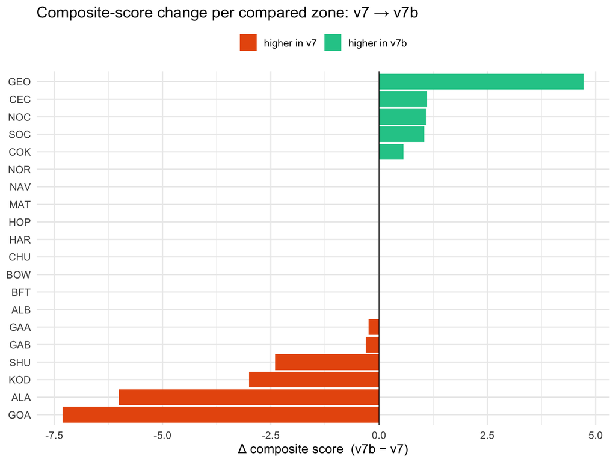

```r
d_plot <- d |>
  mutate(zone_key = factor(zone_key, levels = zone_key[order(delta)]),
         sign = ifelse(delta >= 0, glue("higher in {vb}"), glue("higher in {va}")))

ggplot(d_plot, aes(delta, zone_key, fill = sign)) +
  geom_col() +
  geom_vline(xintercept = 0, linewidth = 0.3) +
  scale_fill_manual(values = setNames(c("#20c997", "#e8590c"),
                                      c(glue("higher in {vb}"), glue("higher in {va}")))) +
  labs(x = glue("Δ composite score  ({vb} − {va})"), y = NULL, fill = NULL,
       title = glue("Composite-score change per compared zone: {va} → {vb}")) +
  theme_minimal(base_size = 12) +
  theme(legend.position = "top")
```

## 4 Component scores

`msens::zone_score_delta()` compares only shared zones and metrics and **returns what it had to drop**, so a component one release lacks is listed, never compared against nothing.

```r
is_component <- function(m) grepl("^extrisk_[a-z_]+_ecoregion_rescaled$", m) |
                            m == "primprod_ecoregion_rescaled"
comp_label <- function(m) ifelse(m == "primprod_ecoregion_rescaled", "primary productivity",
                                 sub("^extrisk_(.*)_ecoregion_rescaled$", "\\1", m))
comp_title <- function(m) tools::toTitleCase(gsub("_", " ", comp_label(m)))

comps <- zd$by_metric |>
  filter(is_component(metric_key)) |>
  mutate(component = comp_label(metric_key)) |>
  arrange(desc(mean_abs_delta))

only_a <- zd$metrics_only_a[is_component(zd$metrics_only_a)]
only_b <- zd$metrics_only_b[is_component(zd$metrics_only_b)]

cat(glue("- components compared: **{nrow(comps)}**  \n",
         "- components only in {va} (listed, not compared): ",
         if (length(only_a)) paste0("`", only_a, "`", collapse = ", ") else "none", "  \n",
         "- components only in {vb} (listed, not compared): ",
         if (length(only_b)) paste0("`", only_b, "`", collapse = ", ") else "none", "\n"))
```

```
- components compared: **8**
- components only in v7 (listed, not compared): none
- components only in v7b (listed, not compared): none
```

### 4.1 Summary by component

```r
comps |>
  transmute(component, metric_key, n = n_zones,
            !!glue("mean {va}") := round(mean_a, 2), !!glue("mean {vb}") := round(mean_b, 2),
            `mean Δ` = round(mean_delta, 2), `mean |Δ|` = round(mean_abs_delta, 2),
            `max |Δ|` = round(max_abs_delta, 2), r = round(cor, 3)) |>
  DT::datatable(rownames = FALSE, options = list(dom = "t", pageLength = 25),
                caption = glue("Per-component delta over the compared zones, {va} → {vb}, sorted by mean |Δ|"))
```

| component | metric_key | n | mean v7 | mean v7b | mean Δ | mean \|Δ\| | max \|Δ\| | r |
| --- | --- | --- | --- | --- | --- | --- | --- | --- |
| turtle | extrisk_turtle_ecoregion_rescaled | 6 | 35.05 | 28.9 | -6.15 | 14.8 | 58.43 | -0.01 |
| bird | extrisk_bird_ecoregion_rescaled | 20 | 53.98 | 53.98 | 0 | 0 | 0 | 1 |
| fish | extrisk_fish_ecoregion_rescaled | 20 | 22.4 | 22.4 | 0 | 0 | 0 | 1 |
| invertebrate | extrisk_invertebrate_ecoregion_rescaled | 20 | 21.09 | 21.09 | 0 | 0 | 0 | 1 |
| primary productivity | primprod_ecoregion_rescaled | 20 | 8.6 | 8.6 | 0 | 0 | 0 | 1 |
| coral | extrisk_coral_ecoregion_rescaled | 20 | 13.5 | 13.5 | 0 | 0 | 0 | 1 |
| mammal | extrisk_mammal_ecoregion_rescaled | 20 | 52.55 | 52.55 | 0 | 0 | 0 | 1 |
| other | extrisk_other_ecoregion_rescaled | 20 | 18.14 | 18.14 | 0 | 0 | 0 | 1 |

### 4.2 Δ by zone × component

One cell per (compared zone, component): Δ = B − A. Sort any column to find where a component moved most.

```r
comp_keys  <- comps$metric_key
comp_delta <- setNames(lapply(comp_keys, metric_delta), comp_keys)

wide <- bind_rows(
    lapply(comp_keys, function(m) comp_delta[[m]] |> transmute(zone_key, component = comp_label(m), delta)),
    d |> transmute(zone_key, component = "COMPOSITE", delta)) |>
  mutate(delta = round(delta, 2)) |>
  pivot_wider(names_from = component, values_from = delta) |>
  left_join(names_draw |> filter(status == "compared") |> select(key_b, zone_name, region), by = c("zone_key" = "key_b")) |>
  relocate(zone_key, zone_name, region, COMPOSITE) |>
  rename(Zone = zone_key, Name = zone_name, Region = region) |>
  arrange(desc(abs(COMPOSITE)))

num_cols <- names(wide)[sapply(wide, is.numeric)]
ds <- div_style(unlist(wide[num_cols]), n = 10)
DT::datatable(wide, rownames = FALSE, options = list(dom = "t", pageLength = 40, scrollX = TRUE),
              caption = glue("Δ ({vb} − {va}) per compared zone and component")) |>
  DT::formatStyle(num_cols, backgroundColor = DT::styleInterval(ds$brks, ds$cols))
```

| Zone | Name | Region | COMPOSITE | turtle | bird | fish | invertebrate | primary productivity | coral | mammal | other |
| --- | --- | --- | --- | --- | --- | --- | --- | --- | --- | --- | --- |
| GOA | Gulf of Alaska | AK | -7.3 | -58.43 | 0 | 0 | 0 | 0 | 0 | 0 | 0 |
| ALA | Aleutian Arc | AK | -6.01 |  | 0 | 0 | 0 | 0 | 0 | 0 | 0 |
| GEO | St. George Basin | AK | 4.72 |  | 0 | 0 | 0 | 0 | 0 | 0 | 0 |
| KOD | Kodiak | AK | -3 |  | 0 | 0 | 0 | 0 | 0 | 0 | 0 |
| SHU | Shumagin | AK | -2.4 |  | 0 | 0 | 0 | 0 | 0 | 0 | 0 |
| CEC | Central California | PA | 1.11 | 8.88 | 0 | 0 | 0 | 0 | 0 | 0 | 0 |
| NOC | Northern California | PA | 1.08 | 8.67 | 0 | 0 | 0 | 0 | 0 | 0 | 0 |
| SOC | Southern California | PA | 1.05 | 8.39 | 0 | 0 | 0 | 0 | 0 | 0 | 0 |
| COK | Cook Inlet | AK | 0.57 |  | 0 | 0 | 0 | 0 | 0 | 0 | 0 |
| GAB | GOA Program Area B | GA | -0.31 | -2.45 | 0 | 0 | 0 | 0 | 0 | 0 | 0 |

[output cut: 10 more lines]

### 4.3 Each component: map and table

**Turtle**

`extrisk_turtle_ecoregion_rescaled` — 6 zones compared; mean |Δ| 14.8, max |Δ| 58.43, r = -0.01.

[interactive chart not shown]

| Program Area (v7b) | Name | Region | v7 | v7b | Δ | Δ % |
| --- | --- | --- | --- | --- | --- | --- |
| GOA | Gulf of Alaska | AK | 69.58 | 11.15 | -58.43 | -84 |
| CEC | Central California | PA | 18.57 | 27.45 | 8.88 | 47.8 |
| NOC | Northern California | PA | 14.43 | 23.1 | 8.67 | 60.1 |
| SOC | Southern California | PA | 26.76 | 35.16 | 8.39 | 31.4 |
| GAB | GOA Program Area B | GA | 26.38 | 23.93 | -2.45 | -9.3 |
| GAA | GOA Program Area A | GA | 54.56 | 52.62 | -1.95 | -3.6 |

**Bird**

`extrisk_bird_ecoregion_rescaled` — 20 zones compared; mean |Δ| 0, max |Δ| 0, r = 1.

[interactive chart not shown]

| Program Area (v7b) | Name | Region | v7 | v7b | Δ | Δ % |
| --- | --- | --- | --- | --- | --- | --- |
| GAB | GOA Program Area B | GA | 85.68 | 85.68 | 0 | 0 |
| ALA | Aleutian Arc | AK | 42.39 | 42.39 | 0 | 0 |
| ALB | Aleutian Basin | AK | 16.47 | 16.47 | 0 | 0 |
| BFT | Beaufort Sea | AK | 5.37 | 5.37 | 0 | 0 |
| BOW | Bowers Basin | AK | 36.84 | 36.84 | 0 | 0 |
| CEC | Central California | PA | 60.17 | 60.17 | 0 | 0 |
| CHU | Chukchi Sea | AK | 10.94 | 10.94 | 0 | 0 |
| COK | Cook Inlet | AK | 98.99 | 98.99 | 0 | 0 |
| GAA | GOA Program Area A | GA | 59.09 | 59.09 | 0 | 0 |
| GEO | St. George Basin | AK | 64.82 | 64.82 | 0 | 0 |

[output cut: 10 more lines]

**Fish**

`extrisk_fish_ecoregion_rescaled` — 20 zones compared; mean |Δ| 0, max |Δ| 0, r = 1.

[interactive chart not shown]

| Program Area (v7b) | Name | Region | v7 | v7b | Δ | Δ % |
| --- | --- | --- | --- | --- | --- | --- |
| GAB | GOA Program Area B | GA | 14.21 | 14.21 | 0 | 0 |
| ALA | Aleutian Arc | AK | 20.52 | 20.52 | 0 | 0 |
| ALB | Aleutian Basin | AK | 2.5 | 2.5 | 0 | 0 |
| BFT | Beaufort Sea | AK | 3.53 | 3.53 | 0 | 0 |
| BOW | Bowers Basin | AK | 7.84 | 7.84 | 0 | 0 |
| CEC | Central California | PA | 12.13 | 12.13 | 0 | 0 |
| CHU | Chukchi Sea | AK | 16.76 | 16.76 | 0 | 0 |
| COK | Cook Inlet | AK | 69.97 | 69.97 | 0 | 0 |
| GAA | GOA Program Area A | GA | 31.38 | 31.38 | 0 | 0 |
| GEO | St. George Basin | AK | 36.91 | 36.91 | 0 | 0 |

[output cut: 10 more lines]

**Invertebrate**

`extrisk_invertebrate_ecoregion_rescaled` — 20 zones compared; mean |Δ| 0, max |Δ| 0, r = 1.

[interactive chart not shown]

| Program Area (v7b) | Name | Region | v7 | v7b | Δ | Δ % |
| --- | --- | --- | --- | --- | --- | --- |
| GAB | GOA Program Area B | GA | 11.83 | 11.83 | 0 | 0 |
| ALA | Aleutian Arc | AK | 14.72 | 14.72 | 0 | 0 |
| ALB | Aleutian Basin | AK | 1.2 | 1.2 | 0 | 0 |
| BFT | Beaufort Sea | AK | 18.06 | 18.06 | 0 | 0 |
| BOW | Bowers Basin | AK | 5.6 | 5.6 | 0 | 0 |
| CEC | Central California | PA | 6.92 | 6.92 | 0 | 0 |
| CHU | Chukchi Sea | AK | 45.84 | 45.84 | 0 | 0 |
| COK | Cook Inlet | AK | 44.1 | 44.1 | 0 | 0 |
| GAA | GOA Program Area A | GA | 31.59 | 31.59 | 0 | 0 |
| GEO | St. George Basin | AK | 32.05 | 32.05 | 0 | 0 |

[output cut: 10 more lines]

**Primary Productivity**

`primprod_ecoregion_rescaled` — 20 zones compared; mean |Δ| 0, max |Δ| 0, r = 1.

[interactive chart not shown]

| Program Area (v7b) | Name | Region | v7 | v7b | Δ | Δ % |
| --- | --- | --- | --- | --- | --- | --- |
| GAB | GOA Program Area B | GA | 2.04 | 2.04 | 0 | 0 |
| ALA | Aleutian Arc | AK | 1.54 | 1.54 | 0 | 0 |
| ALB | Aleutian Basin | AK | 2.1 | 2.1 | 0 | 0 |
| BFT | Beaufort Sea | AK | 4.84 | 4.84 | 0 | 0 |
| BOW | Bowers Basin | AK | 1.83 | 1.83 | 0 | 0 |
| CEC | Central California | PA | 12 | 12 | 0 | 0 |
| CHU | Chukchi Sea | AK | 7.2 | 7.2 | 0 | 0 |
| COK | Cook Inlet | AK | 20.92 | 20.92 | 0 | 0 |
| GAA | GOA Program Area A | GA | 10.81 | 10.81 | 0 | 0 |
| GEO | St. George Basin | AK | 4.48 | 4.48 | 0 | 0 |

[output cut: 10 more lines]

**Coral**

`extrisk_coral_ecoregion_rescaled` — 20 zones compared; mean |Δ| 0, max |Δ| 0, r = 1.

[interactive chart not shown]

| Program Area (v7b) | Name | Region | v7 | v7b | Δ | Δ % |
| --- | --- | --- | --- | --- | --- | --- |
| ALA | Aleutian Arc | AK | 14.93 | 14.93 | 0 | 0 |
| ALB | Aleutian Basin | AK | 5.56 | 5.56 | 0 | 0 |
| BFT | Beaufort Sea | AK | 7 | 7 | 0 | 0 |
| BOW | Bowers Basin | AK | 9.55 | 9.55 | 0 | 0 |
| CEC | Central California | PA | 6.2 | 6.2 | 0 | 0 |
| CHU | Chukchi Sea | AK | 14.24 | 14.24 | 0 | 0 |
| COK | Cook Inlet | AK | 27.49 | 27.49 | 0 | 0 |
| GAA | GOA Program Area A | GA | 11.99 | 11.99 | 0 | 0 |
| GAB | GOA Program Area B | GA | 2.97 | 2.97 | 0 | 0 |
| GEO | St. George Basin | AK | 26.55 | 26.55 | 0 | 0 |

[output cut: 10 more lines]

**Mammal**

`extrisk_mammal_ecoregion_rescaled` — 20 zones compared; mean |Δ| 0, max |Δ| 0, r = 1.

[interactive chart not shown]

| Program Area (v7b) | Name | Region | v7 | v7b | Δ | Δ % |
| --- | --- | --- | --- | --- | --- | --- |
| ALA | Aleutian Arc | AK | 43.42 | 43.42 | 0 | 0 |
| ALB | Aleutian Basin | AK | 53.21 | 53.21 | 0 | 0 |
| BFT | Beaufort Sea | AK | 19.16 | 19.16 | 0 | 0 |
| BOW | Bowers Basin | AK | 57.88 | 57.88 | 0 | 0 |
| CEC | Central California | PA | 54.14 | 54.14 | 0 | 0 |
| CHU | Chukchi Sea | AK | 45.37 | 45.37 | 0 | 0 |
| COK | Cook Inlet | AK | 69.58 | 69.58 | 0 | 0 |
| GAA | GOA Program Area A | GA | 39.78 | 39.78 | 0 | 0 |
| GAB | GOA Program Area B | GA | 56.58 | 56.58 | 0 | 0 |
| GEO | St. George Basin | AK | 75.14 | 75.14 | 0 | 0 |

[output cut: 10 more lines]

**Other**

`extrisk_other_ecoregion_rescaled` — 20 zones compared; mean |Δ| 0, max |Δ| 0, r = 1.

[interactive chart not shown]

| Program Area (v7b) | Name | Region | v7 | v7b | Δ | Δ % |
| --- | --- | --- | --- | --- | --- | --- |
| ALA | Aleutian Arc | AK | 18.35 | 18.35 | 0 | 0 |
| ALB | Aleutian Basin | AK | 4.92 | 4.92 | 0 | 0 |
| BFT | Beaufort Sea | AK | 21.05 | 21.05 | 0 | 0 |
| BOW | Bowers Basin | AK | 9.6 | 9.6 | 0 | 0 |
| CEC | Central California | PA | 4.81 | 4.81 | 0 | 0 |
| CHU | Chukchi Sea | AK | 33.87 | 33.87 | 0 | 0 |
| COK | Cook Inlet | AK | 41.24 | 41.24 | 0 | 0 |
| GAA | GOA Program Area A | GA | 25.54 | 25.54 | 0 | 0 |
| GAB | GOA Program Area B | GA | 5.77 | 5.77 | 0 | 0 |
| GEO | St. George Basin | AK | 30.58 | 30.58 | 0 | 0 |

[output cut: 10 more lines]

### 4.4 Components present in only one version

Listed for reference, **not** compared: their score per zone in the version that has them.

```r
one_sided <- bind_rows(
  scores_a |> filter(metric_key %in% only_a) |> mutate(version = va, unit = unit_label[[unit_a]]),
  scores_b |> filter(metric_key %in% only_b) |> mutate(version = vb, unit = unit_label[[unit_b]]))
if (nrow(one_sided)) {
  one_sided |>
    transmute(version, unit, component = comp_label(metric_key), metric_key, zone = zone_key,
              score = round(score, 2)) |>
    DT::datatable(rownames = FALSE, filter = "top", options = list(pageLength = 25))
} else cat("none — both versions carry the same components.\n")
```

```
none — both versions carry the same components.
```

## 5 All metrics, long form

Every (compared zone, metric) present in both versions — the composite, the components, and the intermediate metrics (`extrisk_*` raw, ecoregion min/max, pre-area-weighting backups). Filter with the boxes above each column and sort by any column.

```r
shared_m <- zd$by_metric$metric_key
long <- bind_rows(lapply(shared_m, function(m) metric_delta(m) |> mutate(metric_key = m))) |>
  left_join(names_draw |> filter(status == "compared") |> select(key_b, region), by = c("zone_key" = "key_b")) |>
  transmute(Zone = zone_key, Region = region, metric_key,
            !!va := round(.data[[va_col]], 3), !!vb := round(.data[[vb_col]], 3),
            `Δ` = round(delta, 3),
            `Δ %` = ifelse(.data[[va_col]] != 0, round(100 * delta / .data[[va_col]], 1), NA)) |>
  arrange(desc(abs(`Δ`)))
DT::datatable(long, rownames = FALSE, filter = "top",
              options = list(pageLength = 20, order = list(list(5, "desc"))),
              caption = glue("{nrow(long)} (zone × metric) pairs shared by {va} and {vb}"))
```

| Zone | Region | metric_key | v7 | v7b | Δ | Δ % |
| --- | --- | --- | --- | --- | --- | --- |
| GOA | AK | extrisk_turtle_ecoregion_rescaled | 69.584 | 11.15 | -58.434 | -84 |
| GOA | AK | extrisk_turtle_ecoregion_rescaled_prepctareaweighting | 69.584 | 26.92 | -42.664 | -61.3 |
| GAB | GA | extrisk_turtle | 196.025 | 183.764 | -12.261 | -6.3 |
| SOC | PA | extrisk_turtle | 119.924 | 110.117 | -9.807 | -8.2 |
| GAA | GA | extrisk_turtle | 284.51 | 274.953 | -9.557 | -3.4 |
| CEC | PA | extrisk_turtle_ecoregion_rescaled | 18.574 | 27.45 | 8.876 | 47.8 |
| CEC | PA | extrisk_turtle_ecoregion_rescaled_prepctareaweighting | 18.574 | 27.45 | 8.876 | 47.8 |
| NOC | PA | extrisk_turtle_ecoregion_rescaled_prepctareaweighting | 14.426 | 23.118 | 8.691 | 60.2 |
| NOC | PA | extrisk_turtle_ecoregion_rescaled | 14.426 | 23.1 | 8.673 | 60.1 |
| SOC | PA | extrisk_turtle_ecoregion_rescaled | 26.765 | 35.156 | 8.391 | 31.4 |

[output cut: 448 more lines]